# Tidy Tuesday - Solar/Wind Utilties

Arnab Panja

12 May 2022

### 1. Introduction

This paper will be primarily focused in showing us a few unique ways to create charts and annotate texts to make the charts aesthetically beautiful. Along its way it will also discuss data wrangling techniques available in **R**. So let us first load the data and see its summary characteristics.

The capacity data has the below summary information. It has 49 observations and 7 variables.

```r
summary(df_capacity)
```

```
##      type                year      standalone_prior   hybrid_prior
##  Length:49          Min.   :2014   Min.   :  0.000   Min.   : 0.000
##  Class :character   1st Qu.:2015   1st Qu.:  3.282   1st Qu.: 0.000
##  Mode  :character   Median :2017   Median : 10.056   Median : 0.000
##                     Mean   :2017   Mean   : 42.812   Mean   : 9.076
##                     3rd Qu.:2019   3rd Qu.: 74.751   3rd Qu.: 2.190
##                     Max.   :2020   Max.   :195.561   Max.   :95.964
##                                                      NA's   :24
##  standalone_new      hybrid_new        total_gw
##  Min.   :  0.000   Min.   : 0.000   Min.   :  0.000
##  1st Qu.:  0.736   1st Qu.: 0.000   1st Qu.:  3.661
##  Median :  8.826   Median : 0.000   Median : 25.406
##  Mean   : 28.870   Mean   : 8.351   Mean   : 80.574
##  3rd Qu.: 44.563   3rd Qu.: 2.972   3rd Qu.:133.376
##  Max.   :115.545   Max.   :63.304   Max.   :462.445
##                    NA's   :24
```

The average cost data has the below summary information. It has 13 observations and 4 variables.

```r
summary(df_average_cost)
```

```
##       year         gas_mwh        solar_mwh         wind_mwh
##  Min.   :2009   Min.   :25.68   Min.   : 21.93   Min.   :16.67
##  1st Qu.:2012   1st Qu.:34.48   1st Qu.: 26.97   1st Qu.:25.11
##  Median :2015   Median :43.17   Median : 46.32   Median :29.00
##  Mean   :2015   Mean   :41.28   Mean   : 65.14   Mean   :35.65
##  3rd Qu.:2018   3rd Qu.:46.08   3rd Qu.: 84.10   3rd Qu.:42.03
##  Max.   :2021   Max.   :57.65   Max.   :167.67   Max.   :74.33
##                                                  NA's   :1
```

### 2. Power Capacity - Variation by Year

We will now study how the capacity has varied over the years for each of the power sources using the df_capacity data frame loaded above.

So let us now get on with some data wrangling the **Tidyverse** way !!! We will also see the use **{patchwork}**, **{ggtext}** packages and also the wonderful plotting facilities of **{ggplot2}** package. Also the power of data wrangling using the **{dplyr}** and **{stringr}** package will also be exhibited through the data visualizations.

```r
df_standalone <- df_capacity |> select(type,
                                       year,
                                       standalone_prior,
                                       standalone_new) |>
  mutate(standalone_total = round(standalone_new + standalone_prior,
                                  digits = 2)) |>
  arrange(type, year) |> select(year,
                                type,
                                total = standalone_total) |>
  mutate(gentype = "Standalone") |>
  group_by(year, type, gentype) |>
  summarise(total = sum(total), .groups = "drop") |>
  ungroup()


df_hybrid <- df_capacity |> select(type,
                                   year,
                                   hybrid_new,
                                   hybrid_prior) |>
  mutate(hybrid_prior = replace_na(hybrid_prior, 0),
         hybrid_new = replace_na(hybrid_new, 0)) |>
  mutate(hybrid_total = round(hybrid_prior + hybrid_new, digits = 2)) |>
  arrange(type, year) |> mutate(total = hybrid_total) |>
  select(year,
         type,
         total) |>
  mutate(gentype = "Hybrid") |>
  group_by(year, type, gentype) |>
  summarise(total = sum(total),
            .groups = "drop") |>
  ungroup()
```

So we have created two intermediate data frames. What is inside them ? Lets fetch the first 10 observations from each of them.

```r
df_standalone |> arrange(-year) |> head(10)
```

```
## # A tibble: 10 x 4
##     year type    gentype     total
##    <dbl> <chr>   <chr>       <dbl>
##  1  2020 Coal    Standalone   0.13
##  2  2020 Gas     Standalone  69.8
##  3  2020 Nuclear Standalone   3.38
##  4  2020 Other   Standalone   6.22
##  5  2020 Solar   Standalone 303.
##  6  2020 Storage Standalone  92.7
##  7  2020 Wind    Standalone 196.
##  8  2019 Coal    Standalone   0.05
##  9  2019 Gas     Standalone  76.7
## 10  2019 Nuclear Standalone   3.33
```

```r
df_hybrid |> arrange(-year) |> head(10)
```

```
## # A tibble: 10 x 4
##     year type    gentype  total
##    <dbl> <chr>   <chr>    <dbl>
##  1  2020 Coal    Hybrid    0
##  2  2020 Gas     Hybrid    4.19
##  3  2020 Nuclear Hybrid    0
##  4  2020 Other   Hybrid    1.7
##  5  2020 Solar   Hybrid  159.
##  6  2020 Storage Hybrid  112.
##  7  2020 Wind    Hybrid   13.2
##  8  2019 Coal    Hybrid    0
##  9  2019 Gas     Hybrid    0.48
## 10  2019 Nuclear Hybrid    0
```

Now let us combine the above two data frames into one which will make this easier to plot the total capacity and its variation by type and year.

```r
df_total_capacity <- bind_rows(df_standalone, df_hybrid)

df_total_capacity |> arrange(-year, type, gentype) |> head(10)
```

```
## # A tibble: 10 x 4
##     year type    gentype     total
##    <dbl> <chr>   <chr>       <dbl>
##  1  2020 Coal    Hybrid       0
##  2  2020 Coal    Standalone   0.13
##  3  2020 Gas     Hybrid       4.19
##  4  2020 Gas     Standalone  69.8
##  5  2020 Nuclear Hybrid       0
##  6  2020 Nuclear Standalone   3.38
##  7  2020 Other   Hybrid       1.7
##  8  2020 Other   Standalone   6.22
##  9  2020 Solar   Hybrid     159.
## 10  2020 Solar   Standalone 303.
```

Now having wrangled the data, let us plot the variation of Standalone power capacity over the years

```r
v_colors <- c("orangered3", "dodgerblue3", "lightslateblue", "goldenrod3",
              "darkslategrey", "darkslategray3", "olivedrab3")

p_standalone <- filter(df_total_capacity,
                       gentype == "Standalone") |>
  ggplot(mapping = aes(x = year,
                       y = total,
                       color = type)) +
  geom_bump(size = 1,
            show.legend = FALSE) +
  geom_point(size = 4,
             show.legend = FALSE) +
  scale_color_manual(values = v_colors) +
  scale_x_continuous(breaks = seq(2014, 2020, 1)) +
  scale_y_continuous(breaks = seq(0, 500, 50)) +
  theme_minimal() +
  theme(legend.position = "bottom") +
  labs(x = NULL,
       y = "Standalone (GWs)",
       title = NULL)



p_total <- df_total_capacity |> group_by(year, type) |>
  summarise(total = sum(total), .groups = "drop") |> ungroup() |>
  ggplot(mapping = aes(x = year,
                       y = total,
                       color = type)) +
  geom_bump(size = 1,
            show.legend = FALSE) +
  geom_point(size = 4,
             show.legend = FALSE) +
  scale_x_continuous(breaks = seq(2014, 2020, 1)) +
  scale_y_continuous(breaks = seq(0, 500, 50)) +
  scale_color_manual(values = v_colors) +
  theme_minimal() +
  theme(legend.position = "bottom") +
  labs(x = NULL,
       y = "Standalone + Hybrid (Gws)",
       title = NULL)
```

The two plots created above are now combined using the **{patchwork}** package.In addition to the combining the **{ggtext}** package is used to highlight texts using the legend colors.

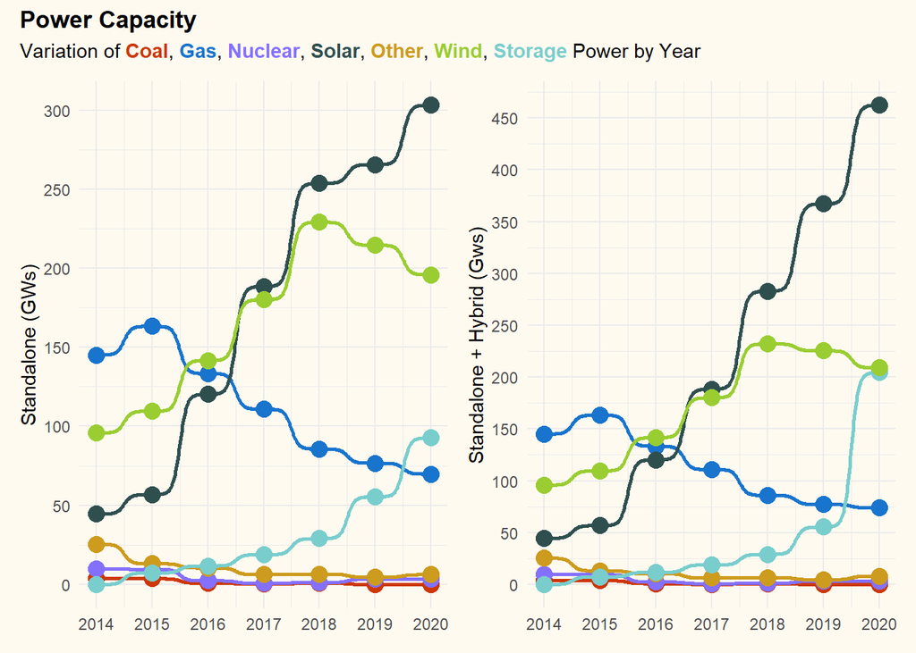

```r
p_patch_plot <- (p_standalone + p_total)  +
  plot_annotation(title = "Power Capacity",
                  subtitle = "Variation of <span style='color:orangered3;'>**Coal**</span>, <span style='color:dodgerblue3;'>**Gas**</span>, <span style='color:lightslateblue;'>**Nuclear**</span>, <span style='color:darkslategrey;'>**Solar**</span>, <span style='color:goldenrod3;'>**Other**</span>, <span style='color:olivedrab3;'>**Wind**</span>, <span style='color:darkslategray3;'>**Storage**</span> Power by Year") +
  plot_layout(guides = "collect") & theme(plot.title = element_text(face = "bold"), plot.subtitle = element_markdown(), plot.background = element_rect(fill = "floralwhite", colour = "floralwhite"))


p_patch_plot
```

**Super !!!** What a **nice combined plot** !!! This is an example of a bump chart prepared using the **{ggbump}** package where a variable can be studied as it progresses by year. Here the variable is Power Capacity.

Needless to emphasize here is the importance of **{patchwork}** package to combine more than one plots.

The combined plot shows that Solar Power capacity has increased the most. Wind Power has also increased by a considerable amount i.e. almost doubled within a span of 6 years from 2014 to 2020. Other sources of power barring Storage power has had reduction in capacity.

Another wonderful feature is the use of markdown elements in subtitle and the color of legends being used as color of texts of the subtitle. This helps us remove the 7 color types in the legend. This makes the final plot neat and much more aesthetically appealing. All of this was made possible by **{ggtext}** package. This package brings the facility of markdown formatting into the plot elements.

We now have a look at how the power generation capacity has changed over the years for both standalone and hybrid. Are we generating more power over the year or not.

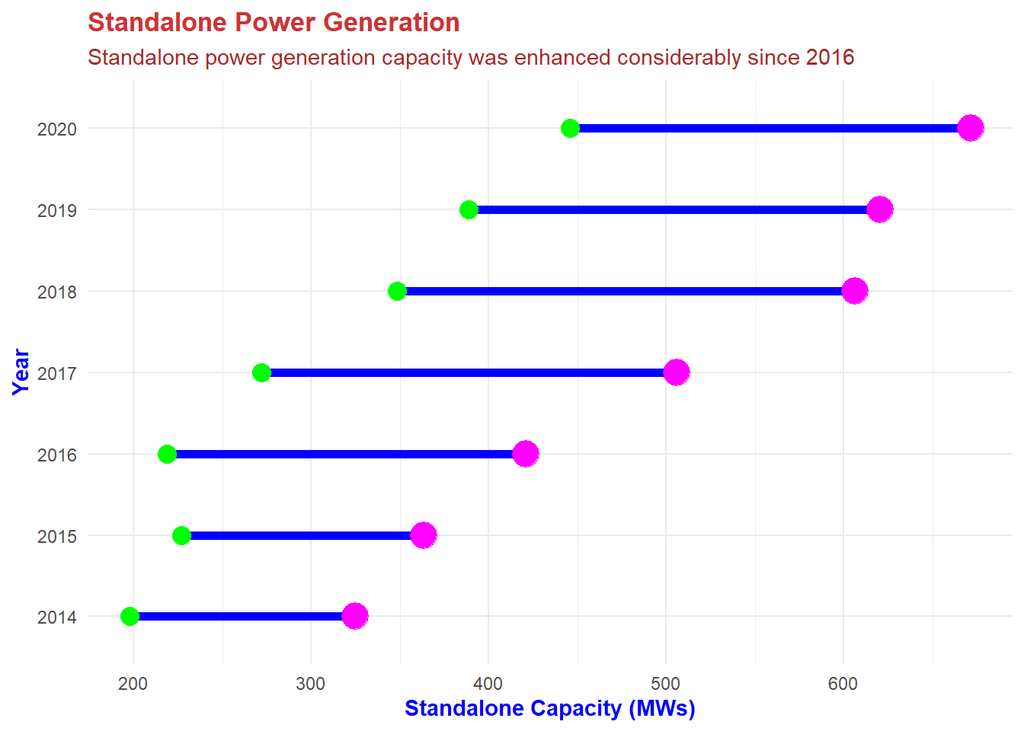

```r
p_standalone_dumbbell <- df_capacity |> mutate(across(.cols = c(3:7),
                             .fns = ~ round(.x, digits = 2))) |>
  mutate(across(.cols = c(3:7), .fns = ~ replace_na(.x, 0))) |>
  group_by(year) |>
  summarise(standalone_prior = sum(standalone_prior),
            standalone_new = sum(standalone_new)) |>
  ungroup() |>
  mutate(standalone_total = standalone_prior + standalone_new) |>
  select(year, standalone_prior, standalone_total) |>
  mutate(year = as.character(year)) |>
  arrange(-as.numeric(year)) |>
  ggplot() +
  geom_dumbbell(mapping = aes(y = year,
                              x = standalone_prior,
                              xend = standalone_total),
                       size = 2,
                       color = "blue",
                       size_x = 4,
                       size_xend = 6,
                       colour_x = "green",
                       colour_xend = "magenta") +
  scale_x_continuous() +
  theme_minimal() +
  theme(plot.title = element_markdown(),
        plot.subtitle = element_markdown(),
        axis.title = element_markdown(colour = "blue",
                                      face = "bold")) +
  labs(x = "Standalone Capacity (MWs)",
       y = "Year",
       title = "<span style='color:brown3;'>**Standalone Power Generation**</span>",
       subtitle = "<span style='color:brown;'>Standalone power generation capacity was enhanced considerably since 2016</span>")

p_standalone_dumbbell
```

So the above plot shows that the standalone power was generated more since 2016 as since that year there has been a large difference between *standalone power prior* and *standalone power new*. **The above data is across all power generation sources**.

Along the similar lines above let us study the power generation of **hybrid power** over these years

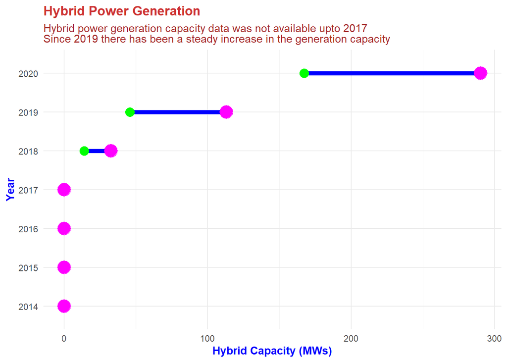

```r
p_hybrid_dumbbell <- df_capacity |> mutate(across(.cols = c(3:7),
                             .fns = ~ round(.x, digits = 2))) |>
  mutate(across(.cols = c(3:7), .fns = ~ replace_na(.x, 0))) |>
  group_by(year) |>
  summarise(hybrid_prior = sum(hybrid_prior),
            hybrid_new = sum(hybrid_new)) |>
  ungroup() |>
  mutate(hybrid_total = hybrid_prior + hybrid_new) |>
  select(year, hybrid_prior, hybrid_total) |>
  mutate(year = as.character(year)) |>
  arrange(-as.numeric(year)) |>
  ggplot() +
  geom_dumbbell(mapping = aes(y = year,
                              x = hybrid_prior,
                              xend = hybrid_total),
                       size = 2,
                       color = "blue",
                       size_x = 4,
                       size_xend = 6,
                       colour_x = "green",
                       colour_xend = "magenta") +
  theme_minimal() +
  theme(plot.title = element_markdown(),
        plot.subtitle = element_markdown(),
        axis.title = element_text(colour = "blue",
                                      face = "bold")) +
  labs(x = "Hybrid Capacity (MWs)",
       y = "Year",
       title = "<span style='color:brown3;'>**Hybrid Power Generation**</span>",
       subtitle = "<span style='color:brown;'>Hybrid power generation capacity data was not available upto 2017<br>Since 2019 there has been a steady increase in the generation capacity</span>")

p_hybrid_dumbbell
```

The above plot shows that no data was available from 2014 to 2017 for Hybrid power capacity. The data from 2018 suggests that power generation has increased significantly since then. **The above data is across all power generation sources**.

### 3. Average Cost - Variation by Year

We will now turn our focus into the study of average cost and its variation by power sources year by year. So let us now work with the average cost data frame

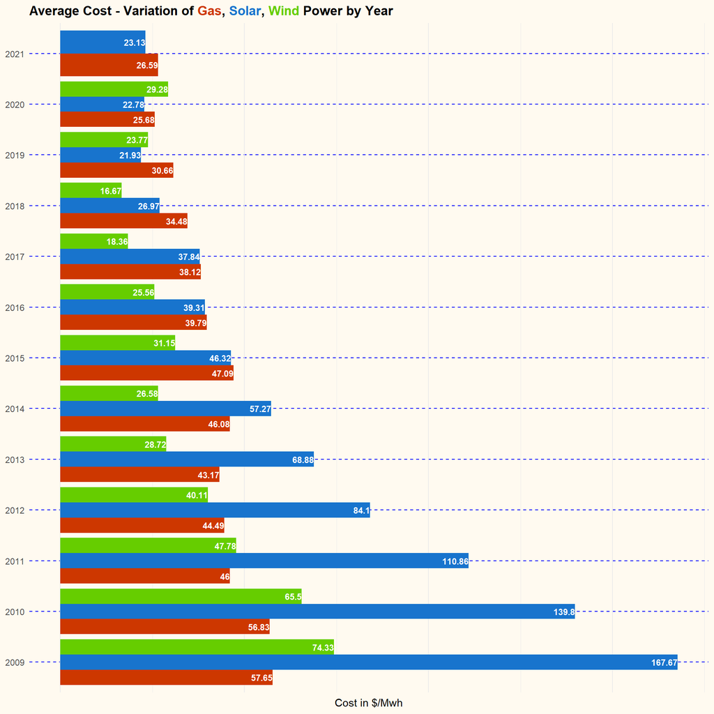

```r
p_avgcost <- df_average_cost |> pivot_longer(cols = ends_with("mwh"),
                                names_to = "gentype",
                                values_to = "mwh") |>
  mutate(gentype = str_replace_all(string = gentype,
                                   pattern = "_mwh",
                                   replacement = ""),
         mwh = round(mwh, digits = 2)) |>
  filter(!is.na(mwh)) |>
  mutate(year = as.character(year)) |>
  ggplot() +
  geom_bar(mapping = aes(x = mwh,
                         y = year,
                         fill = gentype),
           stat = "identity",
           position = position_dodge(width = 0.9),
           show.legend = FALSE) +
  geom_text(mapping = aes(x = mwh,
                          y = year,
                          label = mwh,
                          group = gentype),
            position = position_dodge(width = 0.9),
            size = 3,
            hjust = 1,
            color = "white",
            fontface = "bold") +
  scale_y_discrete(breaks = seq(2008, 2022, 1)) +
  scale_fill_manual(values = c("orangered3",
                               "dodgerblue3",
                               "chartreuse3")) +
  theme_minimal() +
  theme(plot.background = element_rect(fill = "floralwhite",
                                       color = "floralwhite"),
        axis.text.x = element_blank(),
        panel.grid.major.y = element_line(size = 0.5,
                                          colour = "blue",
                                          linetype = "dashed"),
        plot.title = element_markdown(face = "bold")) +
  labs(fill = "Power Source", x = "Cost in $/Mwh", y = NULL,
       title = "Average Cost - Variation of <span style='color:orangered3;'>Gas</span>, <span style='color:dodgerblue3;'>Solar</span>, <span style='color:chartreuse3;'>Wind</span> Power by Year")

p_avgcost
```

The above plot shows cost of power for every source has decreased over the years. This goes hand in hand with the increasing capacity trend as exhibited by the previous plot.

Hope this notebook has provided a good learning tour of the *R* Ecosystem and the benefits it provides for data analysis, data wrangling and data visualization.